# Module 7: Multi Qubit States, Measurements and Gates (Part 1: Multi-Qubit States)

# Summary

- States of multiple qubits
- Measurements of multiple qubits
- Multi-qubit gates

# Multi-Qubit States and Gates

- We need multiple bits to harness the power of classical computation.
- Similarly, more meaningful *quantum* computations require multiple qubits.

## Two qubit states

- A **single bit** has two possible values: 0 and 1
- **Two bits** have four possible values: 00, 01, 10, and 11
- **Single qubit**: standard basis elements are $\left|0 \right\rangle$ and $\left|1\right\rangle$
- **Two qubits**: standard basis elements $\left|00\right\rangle$, $\left|01\right\rangle$, $\left|10\right\rangle$, $\left|11\right\rangle$
- A two-qubit state is a superposition over the standard basis elements:

$$\begin{align}\left|\psi\right\rangle=a_{00}\left|00\right\rangle+a_{01}\left|01\right\rangle+a_{10}\left|10\right\rangle+a_{11}\left|11\right\rangle \end{align}$$

- $\left|\psi\right>$ is a $4$-dimensional vector

$$ \left|\psi\right\rangle = \begin{bmatrix} a_{00}\\ a_{01}\\ a_{10}\\ a_{11}\\ \end{bmatrix}$$

- The standard basis vectors are:

$$\left|00\right\rangle = \begin{bmatrix} 1\\ 0\\ 0\\ 0\\ \end{bmatrix}, \,\,\, \left|01\right\rangle = \begin{bmatrix} 0\\ 1\\ 0\\ 0\\ \end{bmatrix}, \,\,\, \left|10\right\rangle = \begin{bmatrix} 0\\ 0\\ 1\\ 0\\ \end{bmatrix}, \,\,\, \left|11\right\rangle = \begin{bmatrix} 0\\ 0\\ 0\\ 1\\ \end{bmatrix}.$$

$$\begin{align}\left|\psi\right\rangle &=a_{00}\left|00\right\rangle+a_{01}\left|01\right\rangle+a_{10}\left|10\right\rangle+a_{11}\left|11\right\rangle \\ &= \begin{bmatrix} a_{00}\\ a_{01}\\ a_{10}\\ a_{11}\\ \end{bmatrix} \\ &= a_{00} \cdot \begin{bmatrix} 1\\ 0\\ 0\\ 0\\ \end{bmatrix} + a_{01} \cdot \begin{bmatrix} 0\\ 1\\ 0\\ 0\\ \end{bmatrix} + a_{10} \cdot \begin{bmatrix} 0\\ 0\\ 1\\ 0\\ \end{bmatrix} + a_{11} \cdot \begin{bmatrix} 0\\ 0\\ 0\\ 1\\ \end{bmatrix} \,. \end{align}$$

$$\begin{align}\left|\psi\right\rangle=a_{00}\left|00\right\rangle+a_{01}\left|01\right\rangle+a_{10}\left|10\right\rangle+a_{11}\left|11\right\rangle \end{align}$$

- $a_{00}$, $a_{01}$, $a_{10}$, $a_{11}$ satisfy $|a_{00}|^2+|a_{10}|^2+|a_{01}|^2+|a_{11}|^2=1$.

### Combining Two Single Qubit States

Suppose we have two qubits in the states:

- Qubit 1: $\tfrac{1}{\sqrt{2}} \left|0\right\rangle + \tfrac{1}{\sqrt{2}} \left|1\right\rangle$
- Qubit 2: $\left|0\right\rangle$

> How do we represent the joint state of the two qubits as a "two qubit state"?

$$ \left(\tfrac{1}{\sqrt{2}} \left|0\right\rangle + \tfrac{1}{\sqrt{2}} \left|1\right\rangle \right) \left|0\right\rangle \,\,? $$

$$\left(\tfrac{1}{\sqrt{2}} \left|0\right\rangle + \tfrac{1}{\sqrt{2}} \left|1\right\rangle \right) \left|0\right\rangle = \tfrac{1}{\sqrt{2}} \left|00\right\rangle + \tfrac{1}{\sqrt{2}} \left|10\right\rangle \,.$$

- First qubit is in an equal superposition of $\left|0\right\rangle$ and $\left|1\right\rangle$
- The second qubit is always in the state $\left|0\right\rangle$
- A superposition with two "branches" (with equal weights)
  1. The two qubits are in the state $\left|00\right\rangle$
  2. The two qubits are in the state $\left|10\right\rangle$

We will use the notation $ \left(\tfrac{1}{\sqrt{2}} \left|0\right\rangle + \tfrac{1}{\sqrt{2}} \left|1\right\rangle \right) \left|0\right\rangle$ to mean $\tfrac{1}{\sqrt{2}} \left|00\right\rangle + \tfrac{1}{\sqrt{2}} \left|10\right\rangle$.

### General Combination of Two Single Qubit States

- Qubit 1: $\alpha_1 \left|0 \right\rangle+ \beta_1 \left|1\right\rangle$
- Qubit 2: $\alpha_2 \left|0 \right\rangle+ \beta_2 \left|1\right\rangle$

$$\begin{align} \left|\psi\right>&=\big( \alpha_1 \left|0 \right\rangle+ \beta_1 \left|1\right\rangle \big) \big( \alpha_2 \left|0 \right\rangle+ \beta_2 \left|1\right\rangle \big)\\ &=\alpha_1 \alpha_2 \left|00 \right\rangle + \alpha_1 \beta_2 \left|01 \right\rangle + \beta_1 \alpha_2 \left|10 \right\rangle + \beta_1 \beta_2 \left|11 \right\rangle \end{align}$$

**Exercise.** You are given two qubits: the first is in the state $\frac{1}{\sqrt{2}}(\left|0 \right\rangle - \left|1\right\rangle)$, and the second is in the state $\frac{1}{\sqrt{2}}(\left|0 \right\rangle + \left|1\right\rangle)$. What is the joint state of the two qubits? $\,\,\,\,\,\,\,\,\,$

$$\,\,\,\,\,\frac{1}{2} \left|00 \right\rangle + \frac{1}{2} \left|01 \right\rangle - \frac{1}{2} \left|10 \right\rangle - \frac{1}{2} \left|11 \right\rangle$$

> Can any state of two qubits be written in the form $\left|\psi_1\right\rangle \left| \psi_2 \right\rangle$?
- Let $\left| \psi \right\rangle = a_{00}\left|00\right\rangle+a_{01}\left|01\right\rangle+a_{10}\left|10\right\rangle+a_{11}\left|11\right\rangle$.
- The question is whether there always exist $\alpha_1, \alpha_2, \beta_1, \beta_2$ such that:

\begin{align} \left|\psi\right>&=\big( \alpha_1 \left|0 \right\rangle+ \beta_1 \left|1\right\rangle \big) \big( \alpha_2 \left|0 \right\rangle+ \beta_2 \left|1\right\rangle \big)\\ &=\alpha_1 \alpha_2 \left|00 \right\rangle + \alpha_1 \beta_2 \left|01 \right\rangle + \beta_1 \alpha_2 \left|10 \right\rangle + \beta_1 \beta_2 \left|11 \right\rangle \,.\end{align}

- We need $a_{00} = \alpha_1 \alpha_2, \,\,a_{01} = \alpha_1\beta_2$, etc.

$$ \begin{bmatrix} a_{00}\\ a_{01}\\ a_{10}\\ a_{11}\\ \end{bmatrix} = \begin{bmatrix} \alpha_1 \alpha_1\\ \alpha_1 \beta_2\\ \beta_1 \alpha_2\\ \beta_1 \beta_2\\ \end{bmatrix} \,.$$

- **Product states** - Can be written as

$$ \left|\psi\right>=\big( \alpha_1 \left|0 \right\rangle+ \beta_1 \left|1\right\rangle \big) \big( \alpha_2 \left|0 \right\rangle+ \beta_2 \left|1\right\rangle \big) \,.$$

- **Entangled states** - Cannot be written as a *product state*.

**Challenge exercise.** Give an example of a two qubit state that cannot be written as a product state? Show that this is the case.

**Example.** One of the most famous two-qubit states is the *Bell pair* or *EPR pair*. This is the state:

$$\begin{align} \frac{1}{\sqrt{2}} \left| 00 \right\rangle + \frac{1}{\sqrt{2}} \left| 11 \right\rangle. \end{align} $$

- We say that this state is **maximally entangled** because it is 'furthest away' from a product state.

## Quantum states and circuits of n qubits

- A single bit has $2^1$ possible values, a string of two bits has $2^2=4$ possible values, a string of three bits has $2^3=8$..
- Generalizing this, a string of $n$-bits has $2^n$ possible values.
- So, the state of $n$ qubits can be a superposition of all these $2^n$ values.
- The state of $n$-qubits is specified by $2^n$ complex amplitudes, i.e. it is a vector in $2^n$ dimensions.

**Example.** For a three-qubit system, the standard basis states are:

$$\left|000\right\rangle = \begin{bmatrix} \color{red}{1}\\ 0\\ 0\\ 0\\ 0\\ 0\\ 0\\ 0\\ \end{bmatrix}, \,\,\, \left|001\right\rangle = \begin{bmatrix} 0\\ \color{red}{1}\\ 0\\ 0\\ 0\\ 0\\ 0\\ 0\\ \end{bmatrix}, \,\,\, \left|010\right\rangle = \begin{bmatrix} 0\\ 0\\ \color{red}{1}\\ 0\\ 0\\ 0\\ 0\\ 0\\ \end{bmatrix}, \,\,\, \left|011\right\rangle = \begin{bmatrix} 0\\ 0\\ 0\\ \color{red}{1}\\ 0\\ 0\\ 0\\ 0\\ \end{bmatrix}$$

.

$$\, \left|100\right\rangle = \begin{bmatrix} 0\\ 0\\ 0\\ 0\\ \color{red}{1}\\ 0\\ 0\\ 0\\ \end{bmatrix}, \,\,\, \left|101\right\rangle = \begin{bmatrix} 0\\ 0\\ 0\\ 0\\ 0\\ \color{red}{1}\\ 0\\ 0\\ \end{bmatrix}, \,\,\, \left|110\right\rangle = \begin{bmatrix} 0\\ 0\\ 0\\ 0\\ 0\\ 0\\ \color{red}{1}\\ 0\\ \end{bmatrix}, \,\,\, \left|111\right\rangle = \begin{bmatrix} 0\\ 0\\ 0\\ 0\\ 0\\ 0\\ 0\\ \color{red}{1}\\ \end{bmatrix} $$

$$\left| 0 \right\rangle \left( \frac{1}{\sqrt{2}} \left|00 \right\rangle + \frac{1}{\sqrt{2}} \left|11 \right\rangle \right) = \frac{1}{\sqrt{2}} \left|000 \right\rangle + \frac{1}{\sqrt{2}} \left|011 \right\rangle \,. $$

# Module 7: Multi-Qubit States, Measurements and Gates (Part 2: Multi-Qubit Measurements)

### Previously

- A state of two qubits has the form:

$$\left|\psi\right\rangle=a_{00}\left|00\right\rangle+a_{01}\left|01\right\rangle+a_{10}\left|10\right\rangle+a_{11}\left|11\right\rangle \,,$$

where $a_{00}, a_{01}, a_{10}, a_{11}$ are complex numbers satisfying $|a_{00}|^2+|a_{01}|^2 + |a_{10}|^2 + |a_{11}|^2 = 1$.

### Measurement of two qubit states

- A measurement on a state of two qubits corresponds to asking the question:

  > Is the state of the two qubits 00, 01, 10 or 11?
- **Born's rule** for two-qubit states: if we measure $\left|\psi\right\rangle=a_{00}\left|00\right\rangle+a_{01}\left|01\right\rangle+a_{10}\left|10\right\rangle+a_{11}\left|11\right\rangle$, then
  - $\text{Pr}[\text{'00'}]=|a_{00}|^2$
  - $\text{Pr}[\text{'01'}]=|a_{01}|^2$
  - $\text{Pr}[\text{'10'}]=|a_{10}|^2$
  - $\text{Pr}[\text{'11'}]=|a_{11}|^2$
- The requirement that $|a_{00}|^2+|a_{10}|^2+|a_{01}|^2+|a_{11}|^2=1$ comes from Born's rule.

### What is the post-measurement state?

- Upon obtaining outcome 00, the post-measurement state is $\left| 00\right\rangle$.
- Upon obtaining outcome 01, the post-measurement state is $\left| 01\right\rangle$, and so on..

**Example.** If we measure the Bell pair $\begin{align} \tfrac{1}{\sqrt{2}} \left| 00 \right\rangle + \tfrac{1}{\sqrt{2}} \left| 11 \right\rangle, \end{align} $ we get

- outcome '00' with probability $\frac12$
- outcome '11' with probability $\frac12$

### Partial Measurement

> Is it possible to measure just a single qubit out of a two qubit state?
- Basis elements are $\left|00\right\rangle$, $\left|01\right\rangle$, $\left|10\right\rangle$, $\left|11\right\rangle$.
  - Two are such that the first qubit takes the value 0, namely $\left|00\right\rangle$ and $\left|01\right\rangle$.
  - Two are such that the first qubit takes the value 1, namely $\left|10\right\rangle$, $\left|11\right\rangle$.

$$\begin{align} \left|\psi\right\rangle=a_{00}\left|00\right\rangle+a_{01}\left|01\right\rangle+a_{10}\left|10\right\rangle+a_{11}\left|11\right\rangle \end{align}\label{tq_gen_state},$$

- The probability of obtaining measurement outcome 0 for qubit 1 is

$$|a_{00}|^2+|a_{01}|^2$$

- The probability of obtaining outcome 1, i.e. the first qubit is in state 1, is

$$|a_{10}|^2+|a_{11}|^2$$

- When the measurement outcome is 0, the state collapses to a superposition of just $\left|00\right\rangle$ and $\left|01\right\rangle$:

$$\left|\psi'\right\rangle=a_{00}\left|00\right\rangle+a_{01}\left|01\right\rangle$$

- We need to *renormalize* the state:

$$\left|\psi'\right\rangle=\frac{a_{00}\left|00\right\rangle+a_{01}\left|01\right\rangle}{\sqrt{|a_{00}|^2+|a_{01}|^2}}$$

- The original two-qubit state is "projected" onto the vectors $\left|00\right\rangle$ and $\left|01\right\rangle$, and then renormalized.

**Exercise.** You are given the two-qubit state $\frac{1}{\sqrt{2}} \left|00 \right \rangle + \frac{1}{\sqrt{2}} \left|11 \right \rangle$. You measure both qubits. What is the probability of obtaining outcome '01'?

**Exercise.** You are given the two-qubit state $\frac12 \left|00 \right \rangle+ \frac14\left|01 \right \rangle+ \frac14\left|10 \right \rangle+ \sqrt{\frac58} \left|11 \right \rangle$. You measure both qubits. What is the probability of obtaining outcome '01'?

**Exercise.** You are given the two-qubit state $\frac{1}{\sqrt{6}} \left|00 \right \rangle + \frac{1}{\sqrt{6}}\left|01 \right \rangle + \sqrt{\frac23} \left|10 \right \rangle$. You measure the second qubit:

- What is the probability of obtaining outcome 0?
- Suppose you obtained outcome $0$. What is the post-measurement state of the two qubits?

# Module 7: Multi Qubit States (Part 3: Multi qubit gates)

### Recall: Single Qubit Gates

- A **single-qubit quantum gate** is a mapping $U$ from a single-qubit state to another single-qubit state. It is specified by its action on the standard basis states.

\begin{align} & \left| 0\right\rangle \rightarrow a_0 \left| 0\right\rangle + b_0 \left| 1\right\rangle\\ & \left| 1\right\rangle \rightarrow a_1 \left| 0\right\rangle + b_1 \left| 1\right\rangle \,, \end{align}

$\quad \,\,\,\,\,$for some complex numbers $a_0,b_0, a_1, b_1$.

- It acts by **linearity** on all other states:

$$ U (\alpha \left| 0\right\rangle + \beta \left| 1\right\rangle) = \alpha U \left| 0\right\rangle + \beta U \left| 1\right\rangle \,,$$

(i) $\,U \left|0\right\rangle$ and $U \left|1\right\rangle$ should be valid qubit states: $|a_0|^2 + |b_0|^2 = 1$ and $|a_1|^2 + |b_1|^2 = 1$.

(ii) $U$ should preserve *orthogonality*.

Conditions (i) and (ii) define a **unitary** linear transformation.

**Example.** The identity gate:

\begin{align} & \left| 0\right\rangle \rightarrow \left| 0\right\rangle \\ & \left| 1\right\rangle \rightarrow \left| 1\right\rangle \,. \end{align}

- Action on a general state:

$$I (\alpha \left| 0\right\rangle + \beta \left| 1\right\rangle) = \alpha I \left| 0\right\rangle + \beta I \left| 1\right\rangle = \alpha \left| 0\right\rangle + \beta \left| 1\right\rangle \,,$$

$\,\,\,\,\,\,\,\,\,\,$ i.e. it leaves the state unchanged.

**Example.** The quantum analogue of the NOT gate, is commonly known as the $X$ gate. It acts as follows:

\begin{align} & \left| 0\right\rangle \rightarrow \left| 1\right\rangle \\ & \left| 1\right\rangle \rightarrow \left| 0\right\rangle \,. \end{align}

- Action on a general state:

$$X (\alpha \left| 0\right\rangle + \beta \left| 1\right\rangle) = \alpha X \left| 0\right\rangle + \beta X \left| 1\right\rangle = \alpha \left| 1\right\rangle + \beta \left| 0\right\rangle \,,$$

**Example.** The Hadamard gate $H$:

\begin{align} & \left| 0\right\rangle \rightarrow \frac{1}{\sqrt{2}} \left| 0\right\rangle + \frac{1}{\sqrt{2}} \left| 1\right\rangle \\ & \left| 1\right\rangle \rightarrow \frac{1}{\sqrt{2}} \left| 0\right\rangle - \frac{1}{\sqrt{2}} \left| 1\right\rangle \,. \end{align}

## Two-Qubit Gates

- A **two-qubit gate** is a mapping from two-qubit states to two-qubit states. It is specified by its action on the standard basis.
- It acts by **linearity** on all other states.

**Example.** The identity gate maps each standard basis element to itself, i.e.

$$\left|00\right\rangle\rightarrow\left|00\right\rangle\\ \left|01\right\rangle\rightarrow\left|01\right\rangle\\ \left|10\right\rangle\rightarrow\left|10\right\rangle\\ \left|11\right\rangle\rightarrow\left|11\right\rangle,$$

- Action on a general state:

\begin{align} I (a_{00} \left| 00\right\rangle + &a_{01} \left| 01\right\rangle + a_{10} \left| 10\right\rangle + a_{11} \left| 11\right\rangle ) \\ &= a_{00} I \left| 00\right\rangle + a_{01} I \left| 01\right\rangle + a_{10} I \left| 10\right\rangle + a_{11} I \left| 11\right\rangle \\ &= a_{00} \left| 00\right\rangle + a_{01} \left| 01\right\rangle + a_{10} \left| 10\right\rangle + a_{11} \left| 11\right\rangle \,, \end{align}

**Example 2.** The Controlled-NOT (or CNOT) gate acts in the following way:

$$\left|00\right\rangle\rightarrow\left|00\right\rangle\\ \left|01\right\rangle\rightarrow\left|01\right\rangle\\ \left|10\right\rangle\rightarrow\left|11\right\rangle\\ \left|11\right\rangle\rightarrow\left|10\right\rangle$$

- The CNOT gate flips the state of the second qubit (i.e. it applies an X gate) if the first qubit is in the state $\left|1\right\rangle$, does nothing otherwise.
- CNOT is represented as follows:

```python
from qiskit import QuantumCircuit
circ = QuantumCircuit(2)

circ.cx(0,1) # cnot gate from the first qubit to the second.
circ.draw(output='mpl') #draw circuit
```

[output not shown]

**Example.** Another example of a gate with a similar structure is the Controlled-Z gate, which applies a Pauli $Z$ gate on the second qubit "controlled" on the state of the first qubit. It acts as follows:

$$\begin{align}\left|00\right\rangle \,\,\, &\rightarrow\,\,\,\,\,\left|00\right\rangle\\ \left|01\right\rangle \,\,\, &\rightarrow\,\,\,\,\,\left|01\right\rangle\\ \left|10\right\rangle \,\,\, &\rightarrow\,\,\,\,\,\left|10\right\rangle\\ \left|11\right\rangle \,\,\, &\rightarrow -\left|11\right\rangle\end{align}$$

```python
from qiskit import QuantumCircuit
circ = QuantumCircuit(2)

# Controlled-Z gate from the first qubit to the second.
circ.cz(0,1)

circ.draw(output='mpl')
```

[output not shown]

## A general two-qubit quantum gate

- Is a mapping from two-qubit states to two-qubit states. It is specified by its action on the standard basis.
- It acts by **linearity** on all other states.

(i) It maps the two-qubit standard basis states to valid two-qubit states.

(ii) It preserves *orthogonality*.

### Single-qubit gates as a special case of two-qubit gates

> What if we have a two-qubit state, and we want to apply a single-qubit gate only on the first qubit?
- This is certainly possible, and is just a special case of the formalism we described.
- Let's say you want to apply a Pauli $X$ gate on the first qubit, and do nothing to the second qubit (which means applying the identity).
- As a two qubit gate, we write this as $XI$ (meaning $X$ on the first qubit, and $I$, for identity, on the second).

```python
from qiskit import QuantumCircuit
circ = QuantumCircuit(2)
circ.x(0) # Pauli X gate on the first qubit. The argument '0' corresponds to the first qubit.

circ.draw(output='mpl')
```

[output not shown]

**Exercise.** Suppose we initialize two qubits in the state $\left| 0 \right>$. The joint state of this system is $\left| 00 \right>$. Suppose we then apply an $X$ gate to the first qubit. What is the new joint state of the two qubits?

As you can predict, the $XI$ gate acts as follows. It flips the state of the first qubit, and leaves the second qubit unaffected:

$$\left|00\right\rangle\rightarrow\left|10\right\rangle\\ \left|01\right\rangle\rightarrow\left|11\right\rangle\\ \left|10\right\rangle\rightarrow\left|00\right\rangle\\ \left|11\right\rangle\rightarrow\left|01\right\rangle$$

What about applying a Hadamard gate on the first qubit, and doing nothing to the second? We can write this gate as $HI$.

```python
from qiskit import QuantumCircuit
circ = QuantumCircuit(2)

# Hadamard gate on the first qubit.
circ.h(0)

circ.draw(output='mpl')
```

[output not shown]

Recall that the single-qubit Hadamard gate $H$ acts as follows:

\begin{align}\left|0\right\rangle &\rightarrow \frac{1}{\sqrt{2}} \left|0\right\rangle + \frac{1}{\sqrt{2}} \left|1\right\rangle \\ \left|1\right\rangle &\rightarrow \frac{1}{\sqrt{2}} \left|0\right\rangle - \frac{1}{\sqrt{2}} \left|1\right\rangle \end{align}

$HI$ acts on the standard basis as follows:

\begin{align} \left|00\right\rangle &\rightarrow \frac{1}{\sqrt{2}} (\left|0\right\rangle + \left|1\right\rangle) \left|0\right\rangle = \frac{1}{\sqrt{2}} \left|00\right\rangle + \frac{1}{\sqrt{2}} \left|10\right\rangle \\ \left|01\right\rangle &\rightarrow \frac{1}{\sqrt{2}} (\left|0\right\rangle + \left|1\right\rangle) \left|1\right\rangle = \frac{1}{\sqrt{2}} \left|01\right\rangle + \frac{1}{\sqrt{2}} \left|11\right\rangle \\ \left|10\right\rangle &\rightarrow \frac{1}{\sqrt{2}} (\left|0\right\rangle - \left|1\right\rangle) \left|0\right\rangle = \frac{1}{\sqrt{2}} \left|00\right\rangle - \frac{1}{\sqrt{2}} \left|10\right\rangle \\ \left|01\right\rangle &\rightarrow \frac{1}{\sqrt{2}} (\left|0\right\rangle - \left|1\right\rangle) \left|1\right\rangle = \frac{1}{\sqrt{2}} \left|01\right\rangle - \frac{1}{\sqrt{2}} \left|11\right\rangle \end{align}

### Products of single-qubit gates

- We denote by $AB$ the gate that applies $A$ on the first qubit and $B$ on the second.
- For example, $XH$ applies $X$ on the first qubit and $H$ on the second. This is represented in a quantum circuit as follows:

```python
from qiskit import QuantumCircuit
circ = QuantumCircuit(2)
circ.x(0)
circ.h(1)
circ.draw(output='mpl')
```

[output not shown]

The two-qubit gate $XH$ acts on the standard basis elements as follows:

\begin{align} \left|00\right\rangle &\rightarrow X\left|0\right\rangle H \left|0\right\rangle = \left|1\right\rangle \, \frac{1}{\sqrt{2}} (\left|0\right\rangle + \left|1\right\rangle) \\ \left|01\right\rangle &\rightarrow X\left|0\right\rangle H \left|1\right\rangle = \left|1\right\rangle \, \frac{1}{\sqrt{2}} (\left|0\right\rangle - \left|1\right\rangle) \\ \left|10\right\rangle &\rightarrow X\left|1\right\rangle H \left|0\right\rangle = \left|0\right\rangle \, \frac{1}{\sqrt{2}} (\left|0\right\rangle + \left|1\right\rangle) \\ \left|11\right\rangle &\rightarrow X\left|1\right\rangle H \left|1\right\rangle = \left|0\right\rangle \, \frac{1}{\sqrt{2}} (\left|0\right\rangle - \left|1\right\rangle) \\ \end{align}

**Exercise.** Compute the state $H H \left|10 \right\rangle$.

> Remark: Not all two-qubit gates can be written as a product of two single-qubit gates. An example of a two-qubit gate that cannot be written as a product is the CNOT gate!

## Circuit to create a Bell pair

- We wish to create a Bell pair:

$$\begin{align} \frac{1}{\sqrt{2}} \left| 00 \right\rangle + \frac{1}{\sqrt{2}} \left| 11 \right\rangle. \end{align} $$

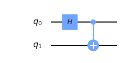

```python
from qiskit import QuantumCircuit
circ = QuantumCircuit(2)

circ.h(0)

circ.cx(0,1)

circ.draw(output='mpl')
```

Let's analyze what this circuit does. The state of the two qubits starts off as $\left| 00 \right\rangle$. After the application of the Hadamard gate, the state of the two qubits is

$$\frac{1}{\sqrt{2}} (\left|0\right\rangle + \left|1\right\rangle) \left|0\right\rangle = \frac{1}{\sqrt{2}} \left|00\right\rangle + \frac{1}{\sqrt{2}} \left|10\right\rangle$$

Applying the CNOT gate (i.e. flip the second qubit if the first is in state '1', and do nothing otherwise) maps this to

$$\frac{1}{\sqrt{2}} \left|00\right\rangle + \frac{1}{\sqrt{2}} \left|11\right\rangle,$$

which is the desired Bell pair.

**Exercise.** The Bell pair is created using $H$ and CNOT. A similar state for a three-qubit system is called the GHZ state: $$\begin{align} \left| \psi_{_{GHZ}}\right>=\frac{1}{\sqrt{2}} \left| 000 \right\rangle + \frac{1}{\sqrt{2}} \left| 111 \right\rangle. \end{align} $$ Using only Hadamard and CNOT gates, construct a circuit that creates this state.

# Quantum computation on many qubits

- Recall: a state of two qubits is a superposition over $2^2 =4$ standard basis states. A state of three qubits over $2^3 = 8$ standard basis states..
- In general, the state of $n$ qubits is a superposition over $2^n$ standard basis states.
- One can certainly keep track of how an $n$ qubit state evolves under the action of quantum gates and measurements *by hand*, by keeping track of all amplitudes. However this quickly becomes intractable as $n$ grows.
- $2^{400}$ amplitudes is more than the atoms in the universe!
- So how can a quantum computer do it? The catch is that a quantum computer does not actually *calculate* all of the amplitudes. Rather, it merely *evolves* the quantum state of, say, $400$ particles by inducing some physical transformations on the state (these correspond to quantum gates if appropriately architectured).
- Even though a state of $n$ qubits is specified by $2^n$ amplitudes, we can only 'access' $n$ bits of information when we measure. So taking advantage of the $2^n$ amplitudes requires delicately orchestrating the destructive and constructive *interferences* amongst them.